# ml

```
classification report：
              precision    recall  f1-score   support

        High       0.51      0.52      0.52       482
         Low       0.68      0.79      0.73      1111
      Medium       0.27      0.14      0.18       381

    accuracy                           0.60      1974
   macro avg       0.49      0.48      0.48      1974
weighted avg       0.56      0.60      0.57      1974
```

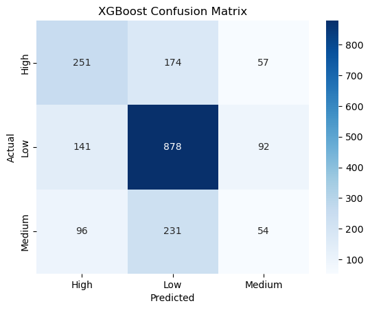

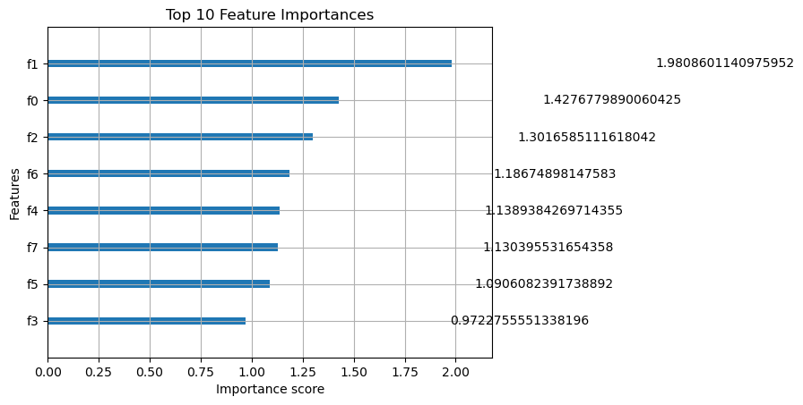

```python
features = ['AVG_ANNUAL_WAGE', 'APPROVAL_RATE', 'POPULATION', 'DENSITY',
            'AVG_RENT_2022', 'UNEMPLOYED', 'EMPLOYED', 'EMPLOYED_PCT']
target = 'LCA_GROUP'

X = df[features]
y = df[target]

# lable（High/Medium/Low）
le = LabelEncoder()
y_encoded = le.fit_transform(y)

# standardize
scaler = StandardScaler()
X_scaled = scaler.fit_transform(X)

# sepeature train and test
X_train, X_test, y_train, y_test = train_test_split(
    X_scaled, y_encoded, test_size=0.2, random_state=42, stratify=y_encoded
)

# train XGBoost
model = xgb.XGBClassifier(use_label_encoder=False, eval_metric='mlogloss')
model.fit(X_train, y_train)

# predict and evaluate
y_pred = model.predict(X_test)
print("classification report：")
print(classification_report(y_test, y_pred, target_names=le.classes_))

# visualize confusion matrix
cm = confusion_matrix(y_test, y_pred)
sns.heatmap(cm, annot=True, fmt='d', xticklabels=le.classes_, yticklabels=le.classes_, cmap='Blues')
plt.xlabel("Predicted")
plt.ylabel("Actual")
plt.title("XGBoost Confusion Matrix")
plt.show()

# plot
xgb.plot_importance(model, importance_type='gain', max_num_features=10, title='Top 10 Feature Importances')
plt.show()
```

Add smote

```python
# recreate LCA_GROUP
bins = [0, 3, 11, df['LCA_APPLICATIONS'].max()]
labels = ['Low', 'Medium', 'High']
df['LCA_GROUP'] = pd.cut(df['LCA_APPLICATIONS'], bins=bins, labels=labels, include_lowest=True)
```

The introduction of SMOTE helped mitigate the effects of class imbalance, especially by improving the model’s ability to correctly classify observations in the underrepresented 'Medium' group. Although overall accuracy slightly decreased, the model became more balanced across classes, reducing bias toward the dominant 'Low' group

```
 Classification Report (SMOTE All Classes):
              precision    recall  f1-score   support

        High       0.51      0.58      0.54       482
         Low       0.76      0.65      0.70      1111
      Medium       0.30      0.37      0.33       381

    accuracy                           0.58      1974
   macro avg       0.52      0.53      0.52      1974
weighted avg       0.61      0.58      0.59      1974
```

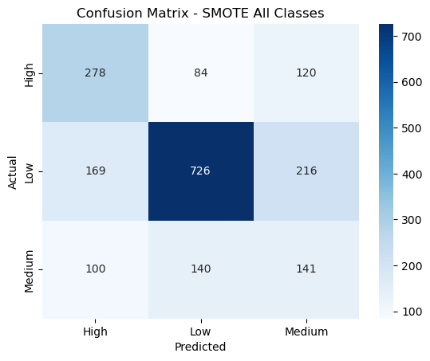

```
Classification Report (SMOTE Medium Enhanced):
              precision    recall  f1-score   support

        High       0.54      0.24      0.33       482
         Low       0.78      0.49      0.60      1111
      Medium       0.24      0.65      0.35       381

    accuracy                           0.46      1974
   macro avg       0.52      0.46      0.43      1974
weighted avg       0.61      0.46      0.49      1974
```

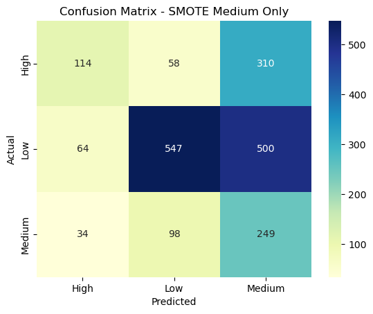

```python
from sklearn.preprocessing import LabelEncoder, StandardScaler
from sklearn.model_selection import train_test_split
from sklearn.metrics import classification_report, confusion_matrix
from imblearn.over_sampling import SMOTE
from collections import Counter
import xgboost as xgb
import matplotlib.pyplot as plt
import seaborn as sns
import pandas as pd

# feature selection
features = ['AVG_ANNUAL_WAGE', 'APPROVAL_RATE', 'POPULATION', 'DENSITY',
            'AVG_RENT_2022', 'UNEMPLOYED', 'EMPLOYED', 'EMPLOYED_PCT']
target = 'LCA_GROUP'

X = df[features]
y = df[target]

# label encoding
le = LabelEncoder()
y_encoded = le.fit_transform(y)

# standardize features
scaler = StandardScaler()
X_scaled = scaler.fit_transform(X)

# seperate train and test
X_train, X_test, y_train, y_test = train_test_split(
    X_scaled, y_encoded, test_size=0.2, random_state=42, stratify=y_encoded
)

# fill missing values
X_train = pd.DataFrame(X_train).fillna(method='ffill')

# Ensure the test set has the same number of features as the training set
X_test = pd.DataFrame(X_test).fillna(method='ffill')

# smote all classes
smote_all = SMOTE(random_state=42)
X_all_resampled, y_all_resampled = smote_all.fit_resample(X_train, y_train)

# train model with smote
model_all = xgb.XGBClassifier(use_label_encoder=False, eval_metric='mlogloss', random_state=42)
model_all.fit(X_all_resampled, y_all_resampled)

# evaluate
y_pred_all = model_all.predict(X_test)
print(" Classification Report (SMOTE All Classes):")
print(classification_report(y_test, y_pred_all, target_names=le.classes_))

# confusion matrix
cm_all = confusion_matrix(y_test, y_pred_all)
sns.heatmap(cm_all, annot=True, fmt='d', cmap='Blues',
            xticklabels=le.classes_, yticklabels=le.classes_)
plt.title("Confusion Matrix - SMOTE All Classes")
plt.xlabel("Predicted")
plt.ylabel("Actual")
plt.show()


# Medium only SMOTE
original_counts = Counter(y_train)
medium_class = list(le.classes_).index('Medium')
sampling_strategy = {
    cls: original_counts[cls] for cls in original_counts
}
sampling_strategy[medium_class] = int(original_counts[medium_class] * 10)

smote_medium = SMOTE(random_state=42, sampling_strategy=sampling_strategy)
X_medium_resampled, y_medium_resampled = smote_medium.fit_resample(X_train, y_train)

# only add weight to Medium
model_medium = xgb.XGBClassifier(
    use_label_encoder=False,
    eval_metric='mlogloss',
    objective='multi:softprob',
    num_class=3,
    random_state=42
)
model_medium.fit(X_medium_resampled, y_medium_resampled)

# evaluate
y_pred_medium = model_medium.predict(X_test)
print("Classification Report (SMOTE Medium Enhanced):")
print(classification_report(y_test, y_pred_medium, target_names=le.classes_))

# confusion matrix
cm_medium = confusion_matrix(y_test, y_pred_medium)
sns.heatmap(cm_medium, annot=True, fmt='d', cmap='YlGnBu',
            xticklabels=le.classes_, yticklabels=le.classes_)
plt.title("Confusion Matrix - SMOTE Medium Only")
plt.xlabel("Predicted")
plt.ylabel("Actual")
plt.show()
```

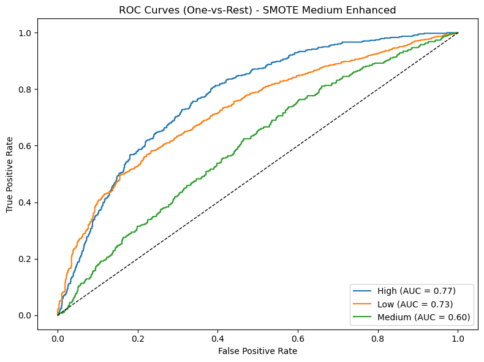

```python
from sklearn.preprocessing import label_binarize
from sklearn.multiclass import OneVsRestClassifier
from sklearn.metrics import roc_curve, auc

# use y_test as binarize
y_test_bin = label_binarize(y_test, classes=[0, 1, 2])

# use OneVsRest to predict
clf_ovr = OneVsRestClassifier(model_medium)
y_score = clf_ovr.fit(X_medium_resampled, y_medium_resampled).predict_proba(X_test)

# Plot ROC curve per class
plt.figure(figsize=(8, 6))
for i in range(y_score.shape[1]):
    fpr, tpr, _ = roc_curve(y_test_bin[:, i], y_score[:, i])
    roc_auc = auc(fpr, tpr)
    plt.plot(fpr, tpr, label=f"{le.classes_[i]} (AUC = {roc_auc:.2f})")

# Reference line
plt.plot([0, 1], [0, 1], 'k--', lw=1)
plt.xlabel("False Positive Rate")
plt.ylabel("True Positive Rate")
plt.title("ROC Curves (One-vs-Rest) - SMOTE Medium Enhanced")
plt.legend(loc='lower right')
plt.tight_layout()
plt.show()
```

```python
print(df.columns)
```

```
Index(['EMPLOYER_STATE', 'EMPLOYER_CITY', 'LCA_APPLICATIONS',
       'AVG_ANNUAL_WAGE', 'MERGE_KEY', 'APPROVAL_RATE', 'POPULATION',
       'DENSITY', 'AVG_RENT_2022', 'UNEMPLOYED', 'EMPLOYED', 'EMPLOYED_PCT',
       'UNEMPLOYED_Z', 'APPLICATION_LEVEL', 'LCA_GROUP'],
      dtype='object')
```

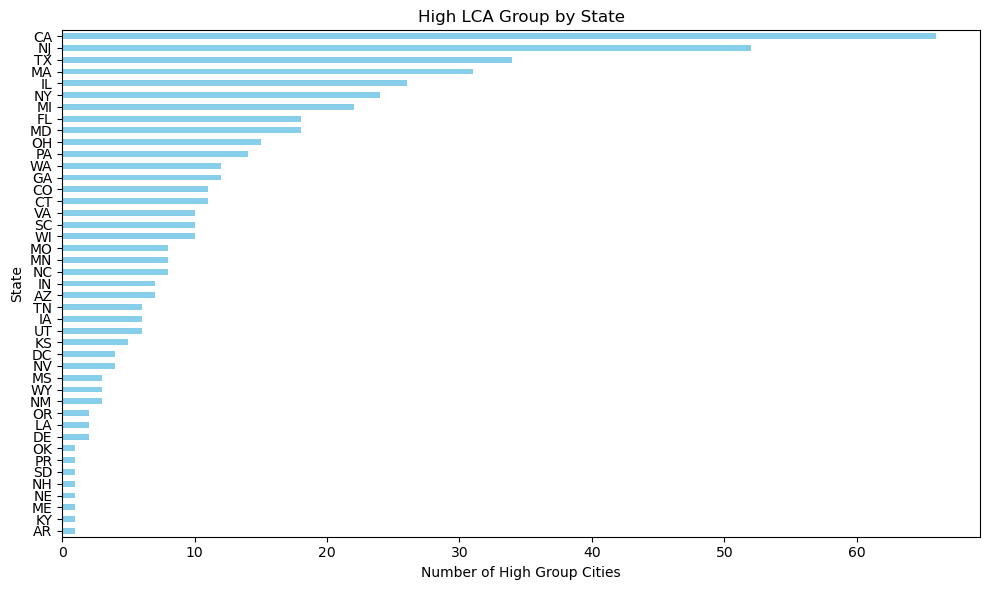

```python
# keep original columns
X = df[features]
y = df[target]
X_original = df[features + ['EMPLOYER_STATE']].copy()



# label（High/Medium/Low）
le = LabelEncoder()
y_encoded = le.fit_transform(y)

scaler = StandardScaler()
X_scaled = scaler.fit_transform(X)

# seperate train and test
X_train, X_test, y_train, y_test = train_test_split(
    X_scaled, y_encoded, test_size=0.2, random_state=42, stratify=y_encoded
)

# test x
_, X_test_orig = train_test_split(
    X_original, test_size=0.2, random_state=42, stratify=y_encoded
)


# trainmodel
model = xgb.XGBClassifier(use_label_encoder=False, eval_metric='mlogloss', random_state=42)
model.fit(X_train, y_train)

# predict
y_pred = model.predict(X_test)

# create data frame
df_test = X_test_orig.copy()
df_test['True_LCA_GROUP'] = le.inverse_transform(y_test)
df_test['Predicted_LCA_GROUP'] = le.inverse_transform(y_pred)

# basesd on the state
high_city_distribution = (
    df_test[df_test['Predicted_LCA_GROUP'] == 'High']
    .groupby('EMPLOYER_STATE')
    .size()
    .sort_values(ascending=False)
)

# visualize
plt.figure(figsize=(10, 6))
high_city_distribution.plot(kind='barh', title='High LCA Group by State', color='skyblue')
plt.xlabel("Number of High Group Cities")
plt.ylabel("State")
plt.gca().invert_yaxis()
plt.tight_layout()
plt.show()
```

The visualization shows that California, New Jersey, and Texas have the highest number of cities falling into the "High" LCA group category. This geographic pattern aligns with demographic and economic expectations—California, for instance, is home to many high-tech hubs that rely heavily on H-1B labor, such as Silicon Valley. This indicates that some of the imbalance in the original dataset may stem from regional industry concentrations, particularly in tech-intensive states. Future modeling could incorporate regional indicators to account for such structural variation.